# cheat sheet

## Deeper updates

We have seen how to perform “deeper searches”, now we will see how to perform “deeper updates”. Basically, the syntax has the same essence: we must have access first to the main field so we can work with the following values:

```
db.products.upadte({"tags": "computers}, {"$set: {"tags.0": "computacion"}}, {"multi": true})
```

Here we specified that, from all the documents which contains the tag “computers”, we wanted to change the first value of the array “tags” from “computers” to “computacion”.

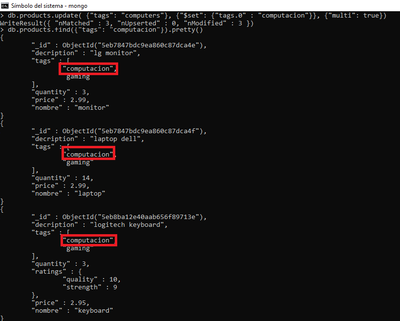

Furthermore, we can also make these kind of updated with no need to specify the position of the value which must be updated:

```
db.products.upadte({"tags": "gaming}, {"$set: {"tags.$": "juegos"}}, {"multi": true})
```

This line of code is similar to the last example. First products with the tag “gaming” were found, and then we let mongodb know that it must change the tag “gaming” to “juegos”, but due to we don’t know the position of that value, we had to put the symbol “$” to let it know that it does not matter the positions, it must change that value.

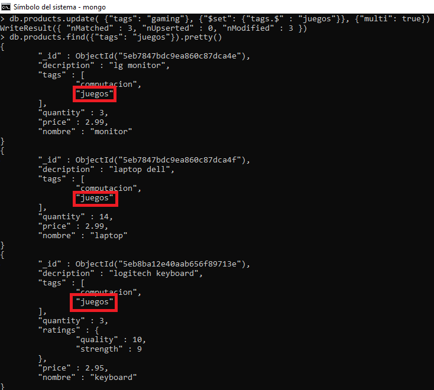

Many of the updates methods we have seen so far are excelent tools to perform changes in our documents. However, there is a problem with these methods, if I run the exact same method more than once to a same document, I will have repeated values which, in some cases, can be difficult to manage. Nevertheless, mongodb provides an operator which help us to avoid this situation. `$addToSet` will add the values specified to it if and only if, these values are not part of a field in a document already. Let’s see an example:

```
db.products.update({"tags": "computation"}, {"$addToSet": {"tags": "computacion"}}, {"multi": true})
```

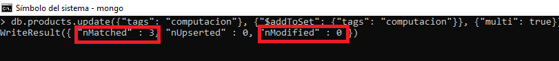

The message that mongodb is printing says that notwithstanding that 3 documents with the tag “computacion” were found, no updates were made because this value already exist in that field in all of the documents found.

Let’s see its behaviour with new values:

```
db.products.update({"tags": "computation"}, {"$addToSet": {"tags": "new_tag"}}, {"multi": true})
```

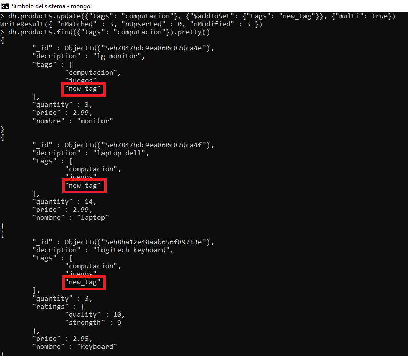

We can see that of the 3 documents that were found, the 3 of them were updated because there was no value “new_tag” in the array tags.

It exist another method to update information named `$push`. This operator will add the value you want to input but it will be added always at the last index.

```
db.products.update({"tags": "juegos"}, {"$push": {"tags": "nuevo"}}, {"multi": true})
```

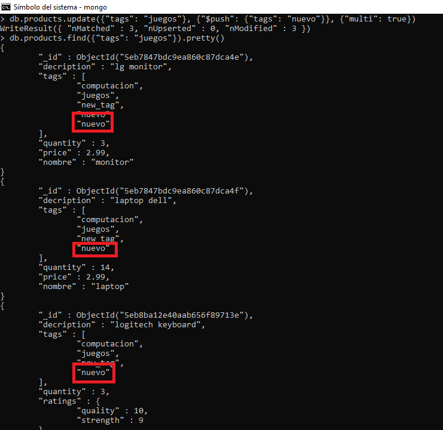

Also we have the $pull operator. $pull will remove any instance of a value from an array with no need to specify the position which must be updated, or to specify that we don’t care about the position as shown is section “deeper updates”.

```
db.products.update({"tags": "juegos"}, {"$pull": {"tags": "nuevo"}}, {"multi": true})
```

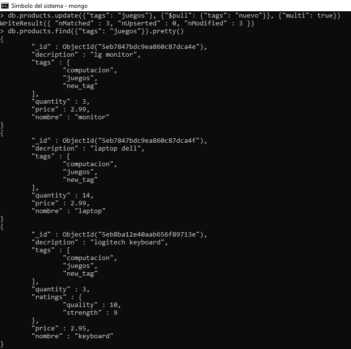

# Aggregation framework

This framework allows for advanced computations. First I want to exemplify how to group data by implementing the aggregation framework.

The `.aggregate()` command takes operators as parameters. The `$group` operator, as its name indicates, it is used to group data by any specified field. Field names that begin with a “$” are called “field paths” and are links to a field in a document.

```
db.brenda.aggregate([{"$group": {"_id": "$vendor_id"}}])
```

The code above will group the documents by the field “$vendor_id” and will return result object containing the unique vendors in the collection.

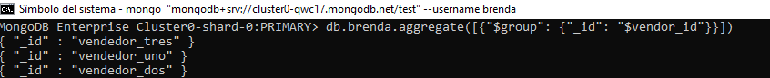

Anything specified after the group key is considered an accumulator. Accumulators take a expression and compute the expression for grouped documents.

In this case, the `$group`operand will find each unique id for the “vendor_id” field in every document, and everytime it finds the same id, it will add 1 for each matching document. The final output it is the id of each vendor and the total number of documents per vendor.

```
db.brenda.aggregate([{"$group": {"_id": "$vendor_id", "total": {"$sum": 1}}}])
```

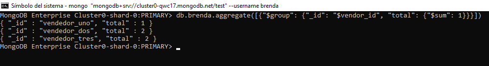

Here is another example of the same line of code as the shown above but this one was tried with a database from Airbnb. The `$group` operand will find each type of property (according to airbnb classification) in every document, and everytime it finds the same type of property, it will add 1 for each matching document.The final output it is the type of property and the total number of documents found per type of property.

As you can see, there is a final message which says: ‘Type it for more’.This is because When there are more than 20 documents, mongodb will iterate through them 20 at a time.

```
db.listingsAndReviews.aggregate([{"$group": {"_id": "$property_type", "total": {"$sum": 1}}}])
```

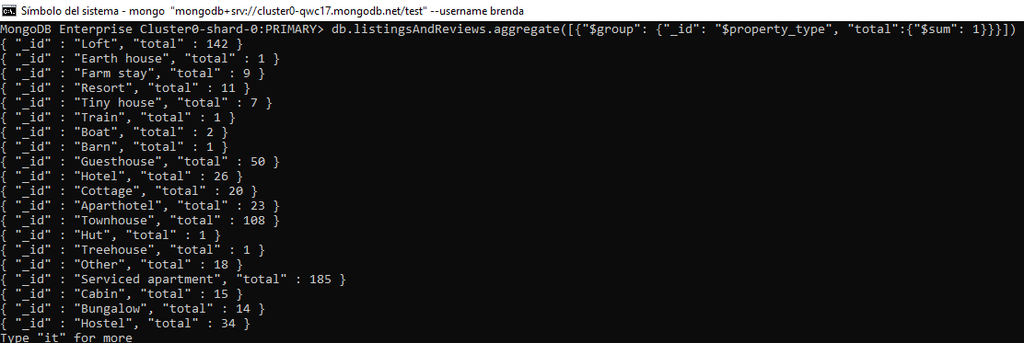

Here is another example of the `$group` command. As the example above, it will do the exact the same thing but now, our output is sorted in descending order and it will just print the first five documents.

```
db.listingsAndReviews.aggregate([{"$group": {"_id": "$property_type", "total": {"$sum": 1}}}, {"$sort": {"total": -1}}, {"limit": 5}])
```

[figure not shown]

This is another example which calculates the average of rooms per type of property.

```
db.listingsAndReviews.aggregate([{"$group": {"_id": "$property_type", "average_rooms": {"$avg": "$bedrooms"}}}])
```

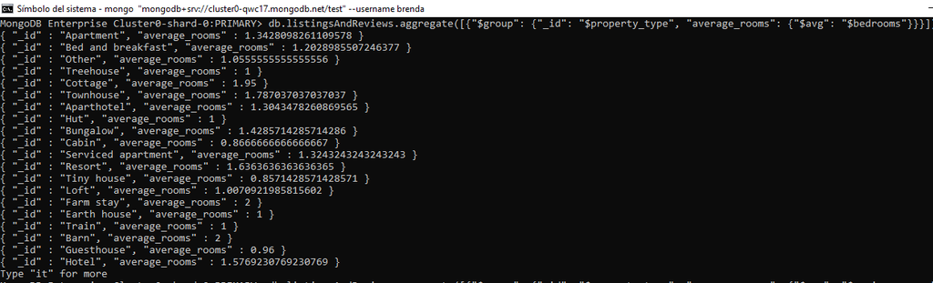

Here we have the max amount of bedrooms per type of property.

```
db.listingsAndReviews.aggregate([{"$group": {"_id": "$property_type", "max_bedrooms": {"$max": "$bedrooms"}}}])
```

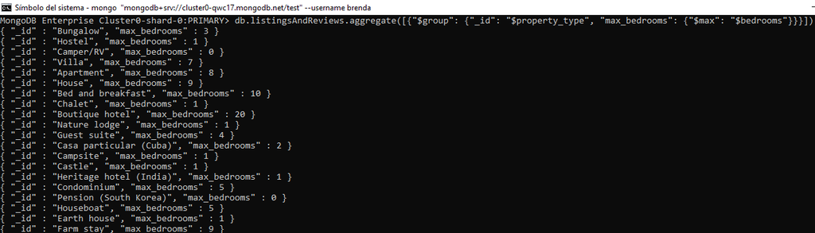

Here we obtained the max and min amount of beds per type of property.

```
db.listingsAndReviews.aggregate([{"$group": {"_id": "$property_type", "max_beds": {"$max": "$beds"}, "min_beds": {"$min": "$beds"}}}])
```

[figure not shown]

If we want to pass multiple methods to an aggregate function, this is the structure that must be followed. As you can see, each method is independent from each other,

```
db.listingsAndReviews.aggregate([
    {"$group": {"_id": "$property_type", "max_beds": {"$max": "$beds"}, "min_beds": {"$min": "$beds"}}},
    {"$sort": {"property_type": -1}},
    {"$limit": 3}
])
```

# Delete data

The document wit the name “keyboard” was deleted from the collection.

```
db.products.remove({"nombre": "keyboard"})
```

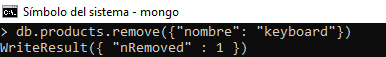

Likewise, it is possible to delete documents with very very specific parameters. We can see that some documents in the collection have an attribute called “ratings”.

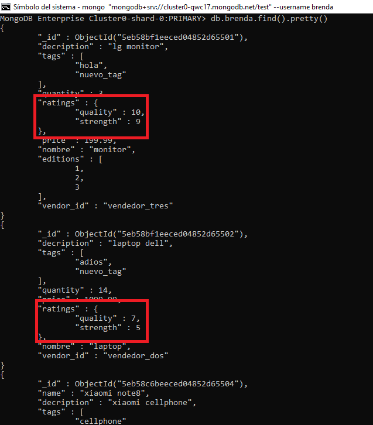

By running this line of code documents with quality = 10 in the ratings attributes were deleted and now we only have two documents.

```
db.brenda.remove({"ratings.quality": 10})
```

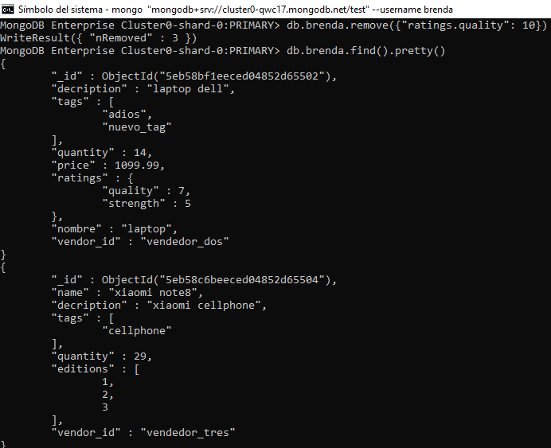

`db.brenda.remove({})`: If we don’t pass any specification to the remove method, then it will remove all documents from the collection. And we can prove it by running the command `find()` or `count()`.

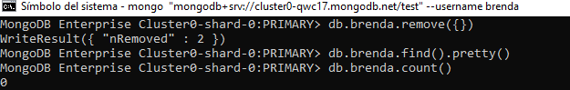